# Bear Creek

Sadie Gill, Mark Tompkins, Erin Cain

July 17, 2019

## Future Data Improvements

None Planned

## Instream Spawning and Rearing Habiat

**Data Source:**

No watershed specific salmonid habitat data was available for Bear Creek. A regional weighted usable area (WUA) relationship with flow was derived for Bear Creek by averaging the WUA values on Battle Creek, Butte Creek, Clear Creek, Cottonwood Creek and Cow Creek. The geomorphic and hydrologic conditions in Bear Creek (watershed area = 649 sqkm, active channel width = 4.3 meters) are similar to those on Battle Creek (watershed area = 957 sqkm; active channel width = 22.5 m), Butte Creek (watershed area = 2123 sqkm; active channel width = 15.2 m), Clear Creek (watershed area = 645 sqkm; active channel width = 18 m), Cottonwood Creek (watershed area = 2444 sqkm; active channel width = 28.25 m), and Cow Creek (watershed area = 1107 sqkm; active channel width = 8.5 m). The regional WUA relationships for Bear Creek were multiplied by the length of spawning and rearing extents mapped by the Science Integration Team (SIT).

### Spawning and Rearing Modeling Details

The spawning and rearing data used for Bear Creek is the regional approximation for the Upper-mid Sacramento River Region. More information about this methodology can be found [here](http://cvpia-habitat-docs-markdown.s3-website-us-west-2.amazonaws.com/watershed/Regional_Approximation.html).

## Floodplain Modeling Details

**Data Source:**

[Scaled from a Deer Creek flow to floodplain area relationship generated with a 1D HEC-RAS hydraulic model](https://s3-us-west-2.amazonaws.com/cvpiahabitat-r-package/cvpia-sit-model-inputs/DRAFT+Deer+Creek+Hydraulic+Models+Tech+Memo+6-08-07.pdf)

No site-specific hydraulic modeling was available for this watershed. A flow to floodplain area relationship was generated for this watershed by scaling the flow to floodplain area relationship for Deer Creek based on hydrologic and geomorphic analyses. Flows and corresponding floodplain areas per unit length were calculated for this watershed as 25% of Deer Creek values based on the ratio of mean flow from December to June between this watershed and Deer Creek. Of the entire mapped 17.3 mile rearing extent in this watershed, 4.3 miles were classified as low gradient and 13 miles were classified as high gradient based on a geomorphic analysis. A scaling factor of 0.1 was applied to the area per unit length for the high gradient extent. No scaling factor was applied to the low gradient extent.

## Floodplain Data

| flow_cfs | FR_floodplain_acres | ST_floodplain_acres | watershed |
| --- | --- | --- | --- |
| 195.5014 | 0.0000000 | 0.0000000 | Bear Creek |
| 220.8912 | 0.2984411 | 0.2984411 | Bear Creek |
| 246.2810 | 0.8764541 | 0.8764541 | Bear Creek |
| 271.6708 | 1.3612654 | 1.3612654 | Bear Creek |
| 297.0606 | 1.8826763 | 1.8826763 | Bear Creek |

*…with 17 more rows*

## Floodplain Plot

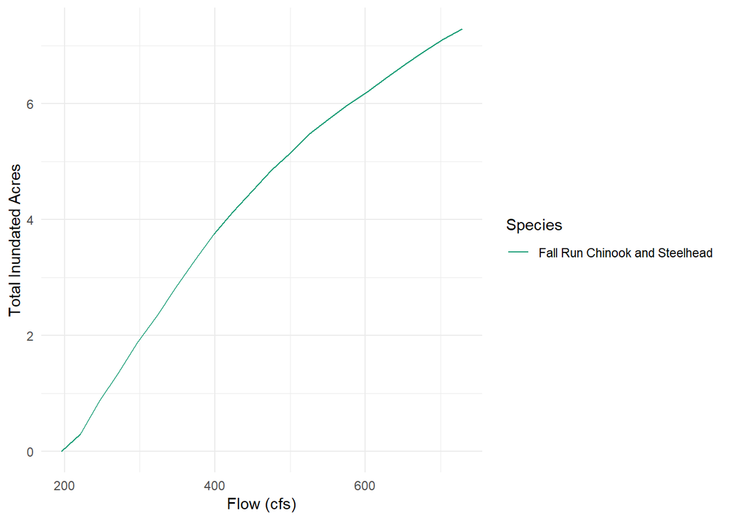